# Project 2: Thera Bank Personal Loan Modelling

### Import the datasets and libraries.

```python
import warnings
warnings.filterwarnings('ignore')
```

```python
import pandas as pd
from sklearn.linear_model import LogisticRegression

# importing ploting libraries
import matplotlib.pyplot as plt
# To enable plotting graphs in Jupyter notebook
%matplotlib inline

#importing seaborn for statistical plots
import seaborn as sns

#import Sklearn package's for data splitting function into training and testing datasets

from sklearn.model_selection import train_test_split

import numpy as np
import os,sys
from scipy import stats

# calculate accuracy measures and confusion matrix
from sklearn import metrics
```

```python
# Remove scientific notations and display numbers with 3 decimal points instead
pd.options.display.float_format = '{:,.3f}'.format

# Increase cell width
from IPython.core.display import display, HTML
display(HTML("<style>.container { width:90% !important; }</style>"))

# Update default style and size of charts
plt.style.use('ggplot')
plt.rcParams['figure.figsize'] = [10, 8]

# Increase max number of rows and columns to display in pandas tables
pd.set_option('display.max_columns', 100)
pd.set_option('display.max_rows', 100)
```

**load data set, check datatype, statistical summary, shape, null values or incorrect imputation**

```python
data = pd.read_csv('Bank_Personal_Loan_Modelling.csv')
data.head()
```

|  | ID | Age | Experience | Income | ZIP Code | Family | CCAvg | Education | Mortgage | Personal Loan | Securities Account | CD Account | Online | CreditCard |
| --- | --- | --- | --- | --- | --- | --- | --- | --- | --- | --- | --- | --- | --- | --- |
| 0 | 1 | 25 | 1 | 49 | 91107 | 4 | 1.600 | 1 | 0 | 0 | 1 | 0 | 0 | 0 |
| 1 | 2 | 45 | 19 | 34 | 90089 | 3 | 1.500 | 1 | 0 | 0 | 1 | 0 | 0 | 0 |
| 2 | 3 | 39 | 15 | 11 | 94720 | 1 | 1.000 | 1 | 0 | 0 | 0 | 0 | 0 | 0 |
| 3 | 4 | 35 | 9 | 100 | 94112 | 1 | 2.700 | 2 | 0 | 0 | 0 | 0 | 0 | 0 |
| 4 | 5 | 35 | 8 | 45 | 91330 | 4 | 1.000 | 2 | 0 | 0 | 0 | 0 | 0 | 1 |

```python
#check the number of rows and columns
data.shape
```

```
(5000, 14)
```

```python
data.info()
```

```
<class 'pandas.core.frame.DataFrame'>
RangeIndex: 5000 entries, 0 to 4999
Data columns (total 14 columns):
 #   Column              Non-Null Count  Dtype
---  ------              --------------  -----
 0   ID                  5000 non-null   int64
 1   Age                 5000 non-null   int64
 2   Experience          5000 non-null   int64
 3   Income              5000 non-null   int64
 4   ZIP Code            5000 non-null   int64
 5   Family              5000 non-null   int64
 6   CCAvg               5000 non-null   float64
 7   Education           5000 non-null   int64
 8   Mortgage            5000 non-null   int64
 9   Personal Loan       5000 non-null   int64
 10  Securities Account  5000 non-null   int64
 11  CD Account          5000 non-null   int64
 12  Online              5000 non-null   int64
 13  CreditCard          5000 non-null   int64
dtypes: float64(1), int64(13)
memory usage: 547.0 KB
```

```python
#convert type for columns that are categorical as such or temporary analysis and drop ID for this analysis

#'Personal Loan', 'Securities Account', 'CD Account', 'Online', 'CreditCard', 'Education', 'Family', 'Zip Code'
data_tmp = data.copy()
data_tmp['Personal Loan'] = data_tmp['Personal Loan'].astype('category')
data_tmp['Securities Account'] = data_tmp['Securities Account'].astype('category')
data_tmp['CD Account'] = data_tmp['CD Account'].astype('category')
data_tmp['Online'] = data_tmp['Online'].astype('category')
data_tmp['CreditCard'] = data_tmp['CreditCard'].astype('category')
data_tmp['Education'] = data_tmp['Education'].astype('category')
data_tmp['Family'] = data_tmp['Family'].astype('category')
#Zip Code is really an ordinal data
data_tmp['ZIP Code'] = data_tmp['ZIP Code'].astype('category')

#drop the ID column as its just an identifier
data_tmp = data_tmp.drop(['ID'], axis =1)

data_tmp.info()
```

```
<class 'pandas.core.frame.DataFrame'>
RangeIndex: 5000 entries, 0 to 4999
Data columns (total 13 columns):
 #   Column              Non-Null Count  Dtype
---  ------              --------------  -----
 0   Age                 5000 non-null   int64
 1   Experience          5000 non-null   int64
 2   Income              5000 non-null   int64
 3   ZIP Code            5000 non-null   category
 4   Family              5000 non-null   category
 5   CCAvg               5000 non-null   float64
 6   Education           5000 non-null   category
 7   Mortgage            5000 non-null   int64
 8   Personal Loan       5000 non-null   category
 9   Securities Account  5000 non-null   category
 10  CD Account          5000 non-null   category
 11  Online              5000 non-null   category
 12  CreditCard          5000 non-null   category
dtypes: category(8), float64(1), int64(4)
memory usage: 263.8 KB
```

```python
#view summary of statistics of numeric fields
data_tmp.describe().T
```

|  | count | mean | std | min | 25% | 50% | 75% | max |
| --- | --- | --- | --- | --- | --- | --- | --- | --- |
| Age | 5,000.000 | 45.338 | 11.463 | 23.000 | 35.000 | 45.000 | 55.000 | 67.000 |
| Experience | 5,000.000 | 20.105 | 11.468 | -3.000 | 10.000 | 20.000 | 30.000 | 43.000 |
| Income | 5,000.000 | 73.774 | 46.034 | 8.000 | 39.000 | 64.000 | 98.000 | 224.000 |
| CCAvg | 5,000.000 | 1.938 | 1.748 | 0.000 | 0.700 | 1.500 | 2.500 | 10.000 |
| Mortgage | 5,000.000 | 56.499 | 101.714 | 0.000 | 0.000 | 0.000 | 101.000 | 635.000 |

We have an abnomality here. We are seeing negative years of experience

```python
#checking for null values
data.isnull().sum()
```

```
ID                    0
Age                   0
Experience            0
Income                0
ZIP Code              0
Family                0
CCAvg                 0
Education             0
Mortgage              0
Personal Loan         0
Securities Account    0
CD Account            0
Online                0
CreditCard            0
dtype: int64
```

```python
#no null data in every column. in this context, all columns should have positive data,
# so lets check for many negative valued records we have (given that we have seem such in the Experience Column)
(data < 0).sum()
```

```
ID                     0
Age                    0
Experience            52
Income                 0
ZIP Code               0
Family                 0
CCAvg                  0
Education              0
Mortgage               0
Personal Loan          0
Securities Account     0
CD Account             0
Online                 0
CreditCard             0
dtype: int64
```

**No null values in the data, however we have the Experience column with 52 records showing negative experience out of 5000 records (which is about 1%)

*Data generally looks ok. But we need to treat the data from the Experience Colums*

```python
## quick look at summary of records for entries with negative experience
NoExp_df = data[(data.Experience < 0)]
NoExp_df.describe().T
```

|  | count | mean | std | min | 25% | 50% | 75% | max |
| --- | --- | --- | --- | --- | --- | --- | --- | --- |
| ID | 52.000 | 2,427.346 | 1,478.834 | 90.000 | 767.250 | 2,783.500 | 3,669.500 | 4,958.000 |
| Age | 52.000 | 24.519 | 1.475 | 23.000 | 24.000 | 24.000 | 25.000 | 29.000 |
| Experience | 52.000 | -1.442 | 0.639 | -3.000 | -2.000 | -1.000 | -1.000 | -1.000 |
| Income | 52.000 | 69.942 | 37.955 | 12.000 | 40.750 | 65.500 | 86.750 | 150.000 |
| ZIP Code | 52.000 | 93,240.962 | 1,611.655 | 90,065.000 | 92,167.750 | 93,060.000 | 94,720.000 | 95,842.000 |
| Family | 52.000 | 2.865 | 0.971 | 1.000 | 2.000 | 3.000 | 4.000 | 4.000 |
| CCAvg | 52.000 | 2.129 | 1.751 | 0.200 | 1.000 | 1.800 | 2.325 | 7.200 |
| Education | 52.000 | 2.077 | 0.837 | 1.000 | 1.000 | 2.000 | 3.000 | 3.000 |
| Mortgage | 52.000 | 43.596 | 90.027 | 0.000 | 0.000 | 0.000 | 0.000 | 314.000 |
| Personal Loan | 52.000 | 0.000 | 0.000 | 0.000 | 0.000 | 0.000 | 0.000 | 0.000 |
| Securities Account | 52.000 | 0.115 | 0.323 | 0.000 | 0.000 | 0.000 | 0.000 | 1.000 |
| CD Account | 52.000 | 0.000 | 0.000 | 0.000 | 0.000 | 0.000 | 0.000 | 0.000 |
| Online | 52.000 | 0.577 | 0.499 | 0.000 | 0.000 | 1.000 | 1.000 | 1.000 |
| CreditCard | 52.000 | 0.288 | 0.457 | 0.000 | 0.000 | 0.000 | 1.000 | 1.000 |

seems like their age range is between 23 and 29.  
**Will substitute negative experience values with the average experience for this age group in the larger data set**

```python
data[(data.Age < 30) & (data.Experience >= 0)].describe().T
```

|  | count | mean | std | min | 25% | 50% | 75% | max |
| --- | --- | --- | --- | --- | --- | --- | --- | --- |
| ID | 436.000 | 2,435.030 | 1,496.256 | 1.000 | 1,111.250 | 2,322.000 | 3,755.500 | 5,000.000 |
| Age | 436.000 | 27.372 | 1.388 | 24.000 | 26.000 | 28.000 | 29.000 | 29.000 |
| Experience | 436.000 | 2.376 | 1.518 | 0.000 | 1.000 | 3.000 | 3.000 | 5.000 |
| Income | 436.000 | 80.314 | 47.147 | 8.000 | 42.000 | 72.000 | 113.000 | 205.000 |
| ZIP Code | 436.000 | 93,237.080 | 1,802.574 | 90,009.000 | 92,023.250 | 93,817.000 | 94,704.500 | 96,651.000 |
| Family | 436.000 | 2.647 | 1.168 | 1.000 | 2.000 | 3.000 | 4.000 | 4.000 |
| CCAvg | 436.000 | 1.921 | 1.655 | 0.000 | 0.800 | 1.600 | 2.500 | 8.300 |
| Education | 436.000 | 1.821 | 0.822 | 1.000 | 1.000 | 2.000 | 3.000 | 3.000 |
| Mortgage | 436.000 | 61.908 | 110.128 | 0.000 | 0.000 | 0.000 | 111.250 | 612.000 |
| Personal Loan | 436.000 | 0.112 | 0.316 | 0.000 | 0.000 | 0.000 | 0.000 | 1.000 |
| Securities Account | 436.000 | 0.087 | 0.282 | 0.000 | 0.000 | 0.000 | 0.000 | 1.000 |
| CD Account | 436.000 | 0.041 | 0.199 | 0.000 | 0.000 | 0.000 | 0.000 | 1.000 |
| Online | 436.000 | 0.567 | 0.496 | 0.000 | 0.000 | 1.000 | 1.000 | 1.000 |
| CreditCard | 436.000 | 0.298 | 0.458 | 0.000 | 0.000 | 0.000 | 1.000 | 1.000 |

```python
#substitute negative years of Experience with 3.
data.loc[data['Experience'] < 0, 'Experience'] = 3
data.describe().T
```

|  | count | mean | std | min | 25% | 50% | 75% | max |
| --- | --- | --- | --- | --- | --- | --- | --- | --- |
| ID | 5,000.000 | 2,500.500 | 1,443.520 | 1.000 | 1,250.750 | 2,500.500 | 3,750.250 | 5,000.000 |
| Age | 5,000.000 | 45.338 | 11.463 | 23.000 | 35.000 | 45.000 | 55.000 | 67.000 |
| Experience | 5,000.000 | 20.151 | 11.390 | 0.000 | 10.000 | 20.000 | 30.000 | 43.000 |
| Income | 5,000.000 | 73.774 | 46.034 | 8.000 | 39.000 | 64.000 | 98.000 | 224.000 |
| ZIP Code | 5,000.000 | 93,152.503 | 2,121.852 | 9,307.000 | 91,911.000 | 93,437.000 | 94,608.000 | 96,651.000 |
| Family | 5,000.000 | 2.396 | 1.148 | 1.000 | 1.000 | 2.000 | 3.000 | 4.000 |
| CCAvg | 5,000.000 | 1.938 | 1.748 | 0.000 | 0.700 | 1.500 | 2.500 | 10.000 |
| Education | 5,000.000 | 1.881 | 0.840 | 1.000 | 1.000 | 2.000 | 3.000 | 3.000 |
| Mortgage | 5,000.000 | 56.499 | 101.714 | 0.000 | 0.000 | 0.000 | 101.000 | 635.000 |
| Personal Loan | 5,000.000 | 0.096 | 0.295 | 0.000 | 0.000 | 0.000 | 0.000 | 1.000 |
| Securities Account | 5,000.000 | 0.104 | 0.306 | 0.000 | 0.000 | 0.000 | 0.000 | 1.000 |
| CD Account | 5,000.000 | 0.060 | 0.238 | 0.000 | 0.000 | 0.000 | 0.000 | 1.000 |
| Online | 5,000.000 | 0.597 | 0.491 | 0.000 | 0.000 | 1.000 | 1.000 | 1.000 |
| CreditCard | 5,000.000 | 0.294 | 0.456 | 0.000 | 0.000 | 0.000 | 1.000 | 1.000 |

*The mean value is not showing much deviation pre-change*

### 2. Performing EDA

```python
#checking for number of unique values per column
data.nunique()
```

```
ID                    5000
Age                     45
Experience              44
Income                 162
ZIP Code               467
Family                   4
CCAvg                  108
Education                3
Mortgage               347
Personal Loan            2
Securities Account       2
CD Account               2
Online                   2
CreditCard               2
dtype: int64
```

```python
data_tmp[data_tmp.columns[data_tmp.dtypes !='category']].skew()
```

```
Age          -0.029
Experience   -0.026
Income        0.841
CCAvg         1.598
Mortgage      2.104
dtype: float64
```

Mortgage column has quite some positive skew as well as the CCAvg

```python
#Number of people with zero and non zero mortgage as well as their percentages
cust_without_mortgage = data[data['Mortgage'] == 0]['Mortgage'].count()
cust_with_mortgage = data[data['Mortgage'] > 0]['Mortgage'].count()
total_cust = data['Mortgage'].count()
print('')
print("Summary of customers with and without mortgages")
print('')
print("Customer with Mortgage   : {0} percentage:({1:2.2f}%)".format(cust_with_mortgage, (cust_with_mortgage/total_cust)*100))
print("Customer without Mortgage: {0} percentage:({1:2.2f}%)".format(cust_without_mortgage, (cust_without_mortgage/total_cust)*100))
```

```
Summary of customers with and without mortgages

Customer with Mortgage   : 1538 percentage:(30.76%)
Customer without Mortgage: 3462 percentage:(69.24%)
```

```python
#Number of people with zero and non zero credit card spending per month as well as their percentages
cust_without_cc_spend = data[data['CCAvg'] == 0]['CCAvg'].count()
cust_with_cc_spend = data[data['CCAvg'] > 0]['CCAvg'].count()
print('')
print("Summary of customers with and without CC Spend Monthly")
print('')
print("Customer with CC Spend   : {0} percentage:({1:2.2f}%)".format(cust_with_cc_spend, (cust_with_cc_spend/total_cust)*100))
print("Customer without CC Spend: {0} percentage:({1:2.2f}%)".format(cust_without_cc_spend, (cust_without_cc_spend/total_cust)*100))
```

```
Summary of customers with and without CC Spend Monthly

Customer with CC Spend   : 4894 percentage:(97.88%)
Customer without CC Spend: 106 percentage:(2.12%)
```

```python
#categorical column summary.
#Education is a categorical data, lets replace with their meaning to help with interpretation,
tempData = data_tmp
tempData['Education'] = tempData['Education'].replace({1: 'UnderGrad', 2: 'Graduate', 3: 'Advanced/Professional'})
tempData['Education'] = tempData['Education'].astype('category')
print('Value Counts for Categorical Data')
print()
for i in list(tempData.columns[tempData.dtypes =='category']):
    if(i != 'ZIP Code'):
        print(tempData[i].value_counts())
        print()
```

```
Value Counts for Categorical Data

1    1472
2    1296
4    1222
3    1010
Name: Family, dtype: int64

UnderGrad                2096
Advanced/Professional    1501
Graduate                 1403
Name: Education, dtype: int64

0    4520
1     480
Name: Personal Loan, dtype: int64

0    4478
1     522
Name: Securities Account, dtype: int64

0    4698
1     302
Name: CD Account, dtype: int64

1    2984
0    2016
Name: Online, dtype: int64

0    3530
1    1470
Name: CreditCard, dtype: int64
```

*CD Account, Seccurities Account, Personal Loan columns are not evenly distributed*

```python
# Zip Code count summary
print(tempData['ZIP Code'].value_counts())
```

```
94720    169
94305    127
95616    116
90095     71
93106     57
        ...
92694      1
94965      1
94970      1
91024      1
9307       1
Name: ZIP Code, Length: 467, dtype: int64
```

**Bivariate and univariate analysis - lets look at pair plots, histplots and correlations**

```python
#we probably should remove zip code from the pair plot
tempData = data.drop(['ID'], axis =1)
tempData.info()
```

```
<class 'pandas.core.frame.DataFrame'>
RangeIndex: 5000 entries, 0 to 4999
Data columns (total 13 columns):
 #   Column              Non-Null Count  Dtype
---  ------              --------------  -----
 0   Age                 5000 non-null   int64
 1   Experience          5000 non-null   int64
 2   Income              5000 non-null   int64
 3   ZIP Code            5000 non-null   int64
 4   Family              5000 non-null   int64
 5   CCAvg               5000 non-null   float64
 6   Education           5000 non-null   int64
 7   Mortgage            5000 non-null   int64
 8   Personal Loan       5000 non-null   int64
 9   Securities Account  5000 non-null   int64
 10  CD Account          5000 non-null   int64
 11  Online              5000 non-null   int64
 12  CreditCard          5000 non-null   int64
dtypes: float64(1), int64(12)
memory usage: 507.9 KB
```

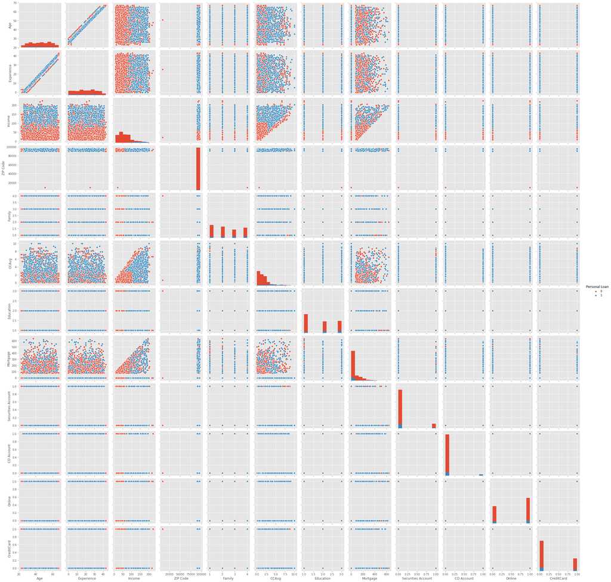

```python
#hueing the pair-plot lets us see the distribution of each feature along with the target variable on the diagonal axis
sns.pairplot(tempData, hue='Personal Loan', diag_kind='hist') #diag_kws={'bw':'1.5'})
```

**observations**  
very strong correlation between Age and Experience. One should probably be dropped.  
People with higher income seemed to get the personal loan

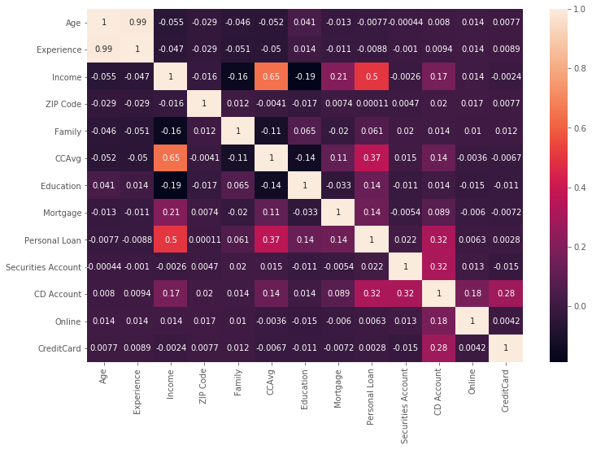

```python
plt.figure(figsize=(12,8))
sns.heatmap(tempData.corr(), annot = True)
plt.show()
```

high correlation between Experience and Age.  
Person Loan showing some strong correlation with Income and to a less extend Average Monthly salary and having a CD Account

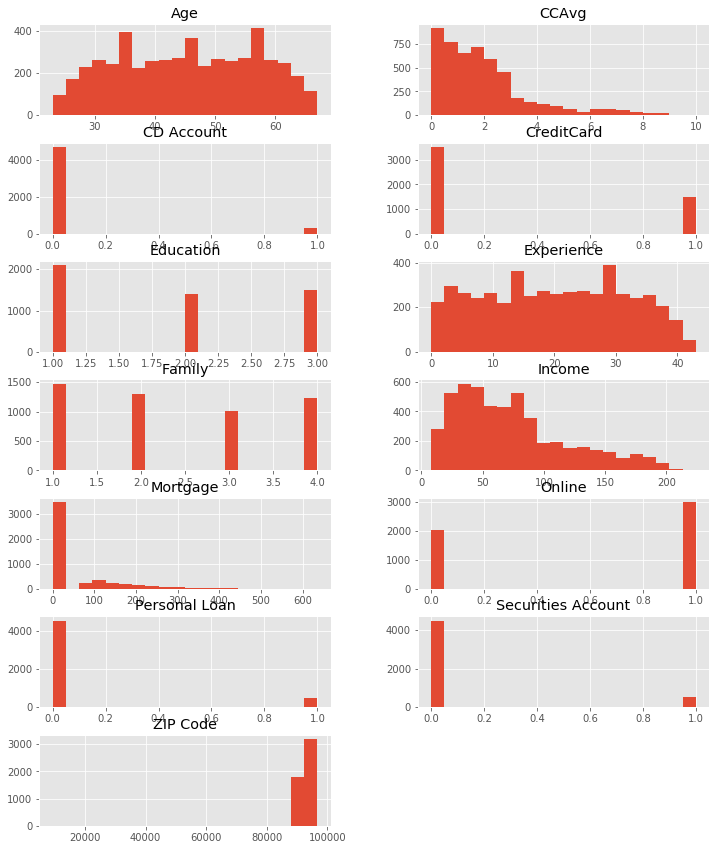

```python
columns = list(tempData)[0:]
tempData[columns].hist(stacked=False, bins=20, figsize=(12,30), layout=(14,2));
```

```python
# View % distribution of Personal Loans taken bassed of family size
pd.crosstab(data['Family'],data['Personal Loan'],normalize='columns')
```

| Personal Loan Family | 0 | 1 |
| --- | --- | --- |
| 1 | 0.302 | 0.223 |
| 2 | 0.263 | 0.221 |
| 3 | 0.194 | 0.277 |
| 4 | 0.241 | 0.279 |

```python
# View % distribution of Personal Loans taken based on level of Education
pd.crosstab(data['Education'],data['Personal Loan'],normalize='columns')
```

| Personal Loan Education | 0 | 1 |
| --- | --- | --- |
| 1 | 0.443 | 0.194 |
| 2 | 0.270 | 0.379 |
| 3 | 0.287 | 0.427 |

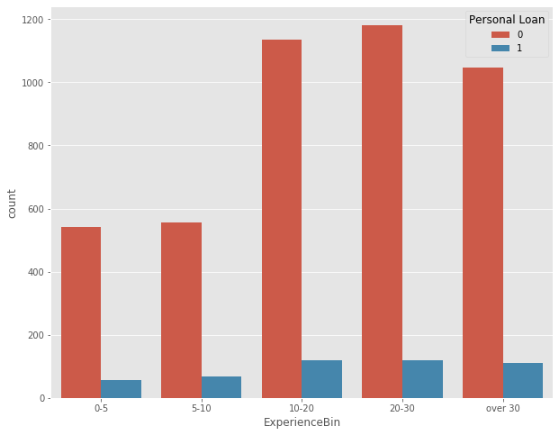

```python
bin_edges = [0, 5, 10, 20, 30, 50]         # edges to define intervals
bin_labels = ['0-5','5-10','10-20','20-30', 'over 30',]
tempData['ExperienceBin'] = pd.cut(tempData['Experience'], bins=bin_edges, labels=bin_labels)
sns.countplot(x = 'ExperienceBin',data=tempData,hue='Personal Loan')
```

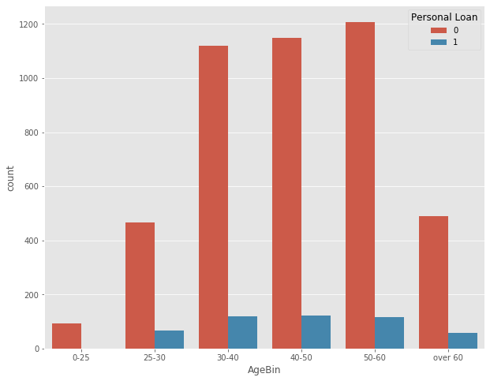

```python
bin_edges = [0, 25, 30, 40, 50, 60, 90]         # edges to define intervals
bin_labels = ['0-25','25-30','30-40','40-50','50-60','over 60',]
tempData['AgeBin'] = pd.cut(tempData['Age'], bins=bin_edges, labels=bin_labels)
sns.countplot(x = 'AgeBin',data=tempData,hue='Personal Loan')
```

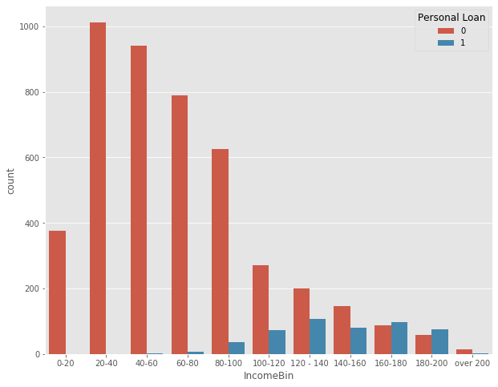

```python
bin_edges = [0, 20, 40, 60, 80, 100, 120, 140, 160, 180, 200, 280]         # edges to define intervals
bin_labels = ['0-20','20-40','40-60','60-80', '80-100', '100-120', '120 - 140', '140-160', '160-180', '180-200', 'over 200']
tempData['IncomeBin'] = pd.cut(tempData['Income'], bins=bin_edges, labels=bin_labels)
sns.countplot(x = 'IncomeBin',data=tempData,hue='Personal Loan')
```

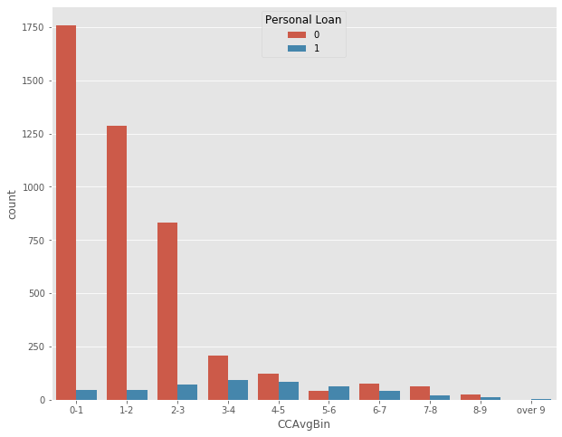

```python
bin_edges = [0, 1, 2, 3, 4, 5, 6, 7, 8, 9, 11]         # edges to define intervals
bin_labels = ['0-1','1-2','2-3','3-4', '4-5', '5-6', '6-7', '7-8', '8-9', 'over 9']
tempData['CCAvgBin'] = pd.cut(tempData['CCAvg'], bins=bin_edges, labels=bin_labels)
sns.countplot(x = 'CCAvgBin',data=tempData,hue='Personal Loan')
```

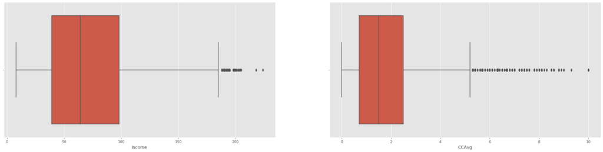

```python
fig, axs = plt.subplots(ncols = 2, figsize = (30, 7))
sns.boxplot(x='Income', data=data, ax=axs[0])
sns.boxplot(x='CCAvg', data=data, ax=axs[1])
```

### Findings

High correlation between Age and experience  
Person Loan showing some strong correlation with Income and to a less extend Average Monthly salary and having a CD Account  
People with higher income seemed to get the personal loan  
More educated people relatively subscibed the Personal Loan at a higher percentage  
People with higher credit cards averages seemed to subscribe to personal loans  
CCAvg has a lot of Outliers. Might be better to perhaps consider doing a different model for thoe with outliers if the number of data is much

### 2.E Model Preperation

**The ID at this point would not add any value to modelling so dropping it**

```python
data_df = data.drop('ID', axis =1 )
data_df.head()
```

|  | Age | Experience | Income | ZIP Code | Family | CCAvg | Education | Mortgage | Personal Loan | Securities Account | CD Account | Online | CreditCard |
| --- | --- | --- | --- | --- | --- | --- | --- | --- | --- | --- | --- | --- | --- |
| 0 | 25 | 1 | 49 | 91107 | 4 | 1.600 | 1 | 0 | 0 | 1 | 0 | 0 | 0 |
| 1 | 45 | 19 | 34 | 90089 | 3 | 1.500 | 1 | 0 | 0 | 1 | 0 | 0 | 0 |
| 2 | 39 | 15 | 11 | 94720 | 1 | 1.000 | 1 | 0 | 0 | 0 | 0 | 0 | 0 |
| 3 | 35 | 9 | 100 | 94112 | 1 | 2.700 | 2 | 0 | 0 | 0 | 0 | 0 | 0 |
| 4 | 35 | 8 | 45 | 91330 | 4 | 1.000 | 2 | 0 | 0 | 0 | 0 | 0 | 1 |

```python
#Quick check for baseline proportion ratio of cutomers with and without personal loans
prop_Y = data_df['Personal Loan'].value_counts(normalize=True)
print(prop_Y)
```

```
0   0.904
1   0.096
Name: Personal Loan, dtype: float64
```

**verifies the 9% ratio of the last campaign**

```python
#convert type for columns that are categorical as such
#'Personal Loan', 'Securities Account', 'CD Account', 'Online', 'CreditCard', 'Education', 'Family', Zip Code

data_df['Personal Loan'] = data_df['Personal Loan'].astype('category')
data_df['Securities Account'] = data_df['Securities Account'].astype('category')
data_df['CD Account'] = data_df['CD Account'].astype('category')
data_df['Online'] = data_df['Online'].astype('category')
data_df['CreditCard'] = data_df['CreditCard'].astype('category')
data_df['Education'] = data_df['Education'].astype('category')
data_df['Family'] = data_df['Family'].astype('category')
data_df['ZIP  Code'] = data_df['ZIP Code'].astype('category')
data_df.info()
```

```
<class 'pandas.core.frame.DataFrame'>
RangeIndex: 5000 entries, 0 to 4999
Data columns (total 14 columns):
 #   Column              Non-Null Count  Dtype
---  ------              --------------  -----
 0   Age                 5000 non-null   int64
 1   Experience          5000 non-null   int64
 2   Income              5000 non-null   int64
 3   ZIP Code            5000 non-null   int64
 4   Family              5000 non-null   category
 5   CCAvg               5000 non-null   float64
 6   Education           5000 non-null   category
 7   Mortgage            5000 non-null   int64
 8   Personal Loan       5000 non-null   category
 9   Securities Account  5000 non-null   category
 10  CD Account          5000 non-null   category
 11  Online              5000 non-null   category
 12  CreditCard          5000 non-null   category
 13  ZIP  Code           5000 non-null   category
dtypes: category(8), float64(1), int64(5)
memory usage: 302.9 KB
```

```python
## Define X and Y variables
#Drop the Zip Code column as it would create a lot of variables
X = data_df.drop(['Personal Loan'], axis=1)
Y = data_df[['Personal Loan']]
```

```python
#Convert categorical vriables to dummy variables
X = pd.get_dummies(X, drop_first=True)
X.head()
```

|  | Age | Experience | Income | ZIP Code | CCAvg | Mortgage | Family_2 | Family_3 | Family_4 | Education_2 | Education_3 | Securities Account_1 | CD Account_1 | Online_1 | CreditCard_1 | ZIP Code_90005 | ZIP Code_90007 | ZIP Code_90009 | ZIP Code_90011 | ZIP Code_90016 | ZIP Code_90018 | ZIP Code_90019 | ZIP Code_90024 | ZIP Code_90025 | ZIP Code_90027 | ZIP Code_90028 | ZIP Code_90029 | ZIP Code_90032 | ZIP Code_90033 | … |
| --- | --- | --- | --- | --- | --- | --- | --- | --- | --- | --- | --- | --- | --- | --- | --- | --- | --- | --- | --- | --- | --- | --- | --- | --- | --- | --- | --- | --- | --- | --- |
| 0 | 25 | 1 | 49 | 91107 | 1.600 | 0 | 0 | 0 | 1 | 0 | 0 | 1 | 0 | 0 | 0 | 0 | 0 | 0 | 0 | 0 | 0 | 0 | 0 | 0 | 0 | 0 | 0 | 0 | 0 | … |
| 1 | 45 | 19 | 34 | 90089 | 1.500 | 0 | 0 | 1 | 0 | 0 | 0 | 1 | 0 | 0 | 0 | 0 | 0 | 0 | 0 | 0 | 0 | 0 | 0 | 0 | 0 | 0 | 0 | 0 | 0 | … |
| 2 | 39 | 15 | 11 | 94720 | 1.000 | 0 | 0 | 0 | 0 | 0 | 0 | 0 | 0 | 0 | 0 | 0 | 0 | 0 | 0 | 0 | 0 | 0 | 0 | 0 | 0 | 0 | 0 | 0 | 0 | … |
| 3 | 35 | 9 | 100 | 94112 | 2.700 | 0 | 0 | 0 | 0 | 1 | 0 | 0 | 0 | 0 | 0 | 0 | 0 | 0 | 0 | 0 | 0 | 0 | 0 | 0 | 0 | 0 | 0 | 0 | 0 | … |
| 4 | 35 | 8 | 45 | 91330 | 1.000 | 0 | 0 | 0 | 1 | 1 | 0 | 0 | 0 | 0 | 1 | 0 | 0 | 0 | 0 | 0 | 0 | 0 | 0 | 0 | 0 | 0 | 0 | 0 | 0 | … |

5 rows × 481 columns

### 3. Data split into 70:30 ratio

```python
##Split into training and test set
from sklearn.model_selection import train_test_split

X_train, X_test, y_train, y_test = train_test_split(X, Y, test_size=0.30,random_state=1)
print('Check spilt ratio on training data for y variable')
print(y_train['Personal Loan'].value_counts(normalize=True))
print()
print('Check spilt ratio on testing data for y variable')
print(y_test['Personal Loan'].value_counts(normalize=True))
```

```
Check spilt ratio on training data for y variable
0   0.905
1   0.095
Name: Personal Loan, dtype: float64

Check spilt ratio on testing data for y variable
0   0.901
1   0.099
Name: Personal Loan, dtype: float64
```

### 4. Use Logistic Regression Model

```python
# Remove scientific notations and display numbers with 3 decimal points instead
pd.options.display.float_format = '{:,.8f}'.format

from sklearn import metrics

from sklearn.linear_model import LogisticRegression

# Fit the model on train
model = LogisticRegression(random_state=42)
model.fit(X_train, y_train)
#predict on test
y_predict = model.predict(X_test)


coef_df = pd.DataFrame(model.coef_)
coef_df['intercept'] = model.intercept_
print(coef_df)
```

[output not shown]

```python
model_score = model.score(X_test, y_test)
print(model_score)
```

```
0.908
```

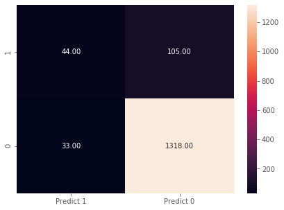

```python
# Remove scientific notations and display numbers with 2 decimal points instead
pd.options.display.float_format = '{:.2f}'.format

cm=metrics.confusion_matrix(y_test, y_predict, labels=[1, 0])

df_cm = pd.DataFrame(cm, index = [i for i in ["1","0"]],
                  columns = [i for i in ["Predict 1","Predict 0"]])
plt.figure(figsize = (7,5))
sns.heatmap(df_cm, fmt='.2f', annot=True)
```

### We have about 105 False Negatives (i.e. We predict 0 but the actual value was 1) and 33 False Positives and our accuracy is 90.8%

**I suspect the Zip Code creates an unneccessary complexity to the model in terms of predicting the outcome.**  
So i would drop it and try to see if we get a worse or better performance

```python
data_df = data.drop(['ID', 'ZIP Code'], axis =1 )

data_df['Personal Loan'] = data_df['Personal Loan'].astype('category')
data_df['Securities Account'] = data_df['Securities Account'].astype('category')
data_df['CD Account'] = data_df['CD Account'].astype('category')
data_df['Online'] = data_df['Online'].astype('category')
data_df['CreditCard'] = data_df['CreditCard'].astype('category')
data_df['Education'] = data_df['Education'].astype('category')
data_df['Family'] = data_df['Family'].astype('category')

X = data_df.drop(['Personal Loan'], axis=1)
Y = data_df[['Personal Loan']]

X = pd.get_dummies(X, drop_first=True)


X_train, X_test, y_train, y_test = train_test_split(X, Y, test_size=0.30,random_state=1)

# Fit the model on train
model = LogisticRegression(random_state=42)
model.fit(X_train, y_train)
#predict on test
y_predict = model.predict(X_test)


coef_df = pd.DataFrame(model.coef_)
coef_df['intercept'] = model.intercept_
print('Equation Coefficients')
print(coef_df)
```

```
Equation Coefficients
      0    1    2    3    4     5    6    7    8    9    10   11    12    13  \
0 -0.43 0.42 0.05 0.23 0.00 -0.44 2.02 1.23 3.25 3.53 -0.32 2.60 -0.47 -0.77

   intercept
0      -0.51
```

```python
model_score = model.score(X_test, y_test)
print(model_score)
```

```
0.95
```

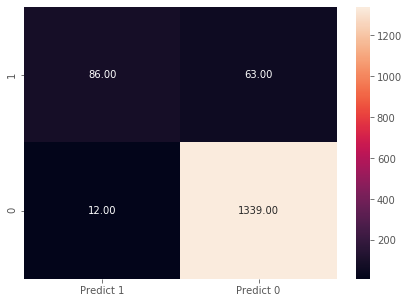

```python
# Remove scientific notations and display numbers with 2 decimal points instead
pd.options.display.float_format = '{:.2f}'.format

cm=metrics.confusion_matrix(y_test, y_predict, labels=[1, 0])

df_cm = pd.DataFrame(cm, index = [i for i in ["1","0"]],
                  columns = [i for i in ["Predict 1","Predict 0"]])
plt.figure(figsize = (7,5))
sns.heatmap(df_cm, fmt='.2f', annot=True)
```

### We have about 63 False Negatives (i.e. We predict 0 but the actual value was 1) and 12 False Positives and our accuracy is 95%

### Lets use the pvalue test to ssee if we can drop more columns

```python
#Build the logistic regression model
import statsmodels.api as sm

logit = sm.Logit(y_train, sm.add_constant(X_train))
lg = logit.fit()
```

```
Optimization terminated successfully.
         Current function value: 0.107503
         Iterations 10
```

```python
#Summary of logistic regression
from scipy import stats
stats.chisqprob = lambda chisq, df: stats.chi2.sf(chisq, df)
print(lg.summary())
```

```
                           Logit Regression Results
==============================================================================
Dep. Variable:          Personal Loan   No. Observations:                 3500
Model:                          Logit   Df Residuals:                     3485
Method:                           MLE   Df Model:                           14
Date:                Fri, 10 Jul 2020   Pseudo R-squ.:                  0.6565
Time:                        14:33:34   Log-Likelihood:                -376.26
converged:                       True   LL-Null:                       -1095.5
Covariance Type:            nonrobust   LLR p-value:                8.750e-299
========================================================================================
                           coef    std err          z      P>|z|      [0.025      0.975]
----------------------------------------------------------------------------------------
const                  -14.0692      2.093     -6.721      0.000     -18.172      -9.966
Age                      0.0256      0.076      0.339      0.735      -0.123       0.174
Experience              -0.0207      0.076     -0.272      0.785      -0.170       0.128
Income                   0.0629      0.004     16.324      0.000       0.055       0.070
CCAvg                    0.2464      0.058      4.240      0.000       0.132       0.360
Mortgage                 0.0009      0.001      1.217      0.223      -0.001       0.002
Family_2                 0.0325      0.291      0.111      0.911      -0.539       0.604
Family_3                 2.4895      0.315      7.892      0.000       1.871       3.108
Family_4                 1.6453      0.311      5.299      0.000       1.037       2.254
Education_2              4.0014      0.347     11.528      0.000       3.321       4.682
Education_3              4.2581      0.347     12.276      0.000       3.578       4.938
Securities Account_1    -1.0683      0.406     -2.630      0.009      -1.864      -0.272
CD Account_1             3.7107      0.437      8.483      0.000       2.853       4.568
Online_1                -0.5849      0.206     -2.840      0.005      -0.988      -0.181
CreditCard_1            -0.9962      0.270     -3.695      0.000      -1.525      -0.468
========================================================================================

Possibly complete quasi-separation: A fraction 0.14 of observations can be
perfectly predicted. This might indicate that there is complete
quasi-separation. In this case some parameters will not be identified.
```

```python
#Calculate Odds Ratio, probability
##create a data frame to collate Odds ratio, probability and p-value of the coef
lgcoef = pd.DataFrame(lg.params, columns=['coef'])
lgcoef.loc[:, "Odds_ratio"] = np.exp(lgcoef.coef)
lgcoef['probability'] = lgcoef['Odds_ratio']/(1+lgcoef['Odds_ratio'])
lgcoef['pval']=lg.pvalues
pd.options.display.float_format = '{:.2f}'.format
```

```python
# FIlter by significant p-value (pval <0.1) and sort descending by Odds ratio
lgcoef = lgcoef.sort_values(by="Odds_ratio", ascending=False)
pval_filter = lgcoef['pval']<=0.1
lgcoef[pval_filter]
```

|  | coef | Odds_ratio | probability | pval |
| --- | --- | --- | --- | --- |
| Education_3 | 4.26 | 70.68 | 0.99 | 0.00 |
| Education_2 | 4.00 | 54.67 | 0.98 | 0.00 |
| CD Account_1 | 3.71 | 40.88 | 0.98 | 0.00 |
| Family_3 | 2.49 | 12.06 | 0.92 | 0.00 |
| Family_4 | 1.65 | 5.18 | 0.84 | 0.00 |
| CCAvg | 0.25 | 1.28 | 0.56 | 0.00 |
| Income | 0.06 | 1.06 | 0.52 | 0.00 |
| Online_1 | -0.58 | 0.56 | 0.36 | 0.00 |
| CreditCard_1 | -1.00 | 0.37 | 0.27 | 0.00 |
| Securities Account_1 | -1.07 | 0.34 | 0.26 | 0.01 |
| const | -14.07 | 0.00 | 0.00 | 0.00 |

```python
data_df = data.drop(['ID', 'ZIP Code', 'Age', 'Experience', 'Mortgage'], axis =1 )

data_df['Personal Loan'] = data_df['Personal Loan'].astype('category')
data_df['Securities Account'] = data_df['Securities Account'].astype('category')
data_df['CD Account'] = data_df['CD Account'].astype('category')
data_df['Online'] = data_df['Online'].astype('category')
data_df['CreditCard'] = data_df['CreditCard'].astype('category')
data_df['Education'] = data_df['Education'].astype('category')
data_df['Family'] = data_df['Family'].astype('category')

X = data_df.drop(['Personal Loan'], axis=1)
Y = data_df[['Personal Loan']]

X = pd.get_dummies(X, drop_first=True)


X_train, X_test, y_train, y_test = train_test_split(X, Y, test_size=0.30,random_state=1)
```

```python
from sklearn.metrics import confusion_matrix, recall_score, precision_score, f1_score, roc_auc_score,accuracy_score
from sklearn.linear_model import LogisticRegression


logreg = LogisticRegression(random_state=42)
logreg.fit(X_train, y_train)
```

```
LogisticRegression(C=1.0, class_weight=None, dual=False, fit_intercept=True,
                   intercept_scaling=1, l1_ratio=None, max_iter=100,
                   multi_class='auto', n_jobs=None, penalty='l2',
                   random_state=42, solver='lbfgs', tol=0.0001, verbose=0,
                   warm_start=False)
```

```python
y_predict = logreg.predict(X_test)
```

*Lets view the ROC Curve to see the right trade off balance for the cut off threshold*

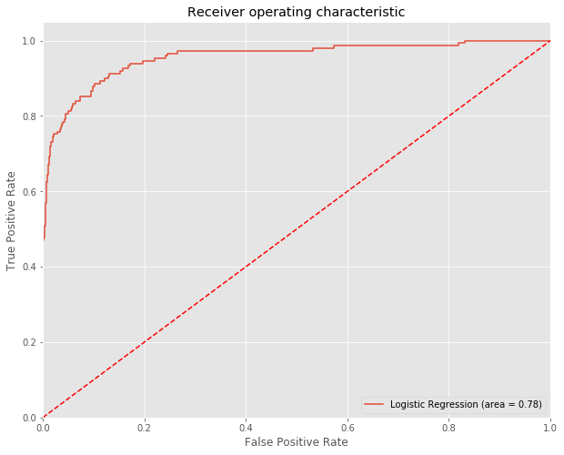

```python
#AUC ROC curve
from sklearn.metrics import roc_auc_score
from sklearn.metrics import roc_curve

logit_roc_auc = roc_auc_score(y_test, logreg.predict(X_test))
fpr, tpr, thresholds = roc_curve(y_test, logreg.predict_proba(X_test)[:,1])
plt.figure()
plt.plot(fpr, tpr, label='Logistic Regression (area = %0.2f)' % logit_roc_auc)
plt.plot([0, 1], [0, 1],'r--')
plt.xlim([0.0, 1.0])
plt.ylim([0.0, 1.05])
plt.xlabel('False Positive Rate')
plt.ylabel('True Positive Rate')
plt.title('Receiver operating characteristic')
plt.legend(loc="lower right")
plt.savefig('Log_ROC')
plt.show()
```

```python
## function to get confusion matrix in a proper format
def draw_cm( actual, predicted ):
    cm = confusion_matrix( actual, predicted)
    sns.heatmap(cm, annot=True,  fmt='.2f', xticklabels = [0,1] , yticklabels = [0,1] )
    plt.ylabel('Observed')
    plt.xlabel('Predicted')
    plt.show()
```

```
Trainig accuracy 0.962

Testing accuracy 0.9513333333333334

Confusion Matrix
```

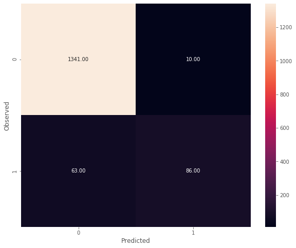

```
None

Recall: 0.5771812080536913

Precision: 0.8958333333333334

F1 Score: 0.7020408163265307

Roc Auc Score: 0.7848896417766605
```

```python
print("Trainig accuracy",logreg.score(X_train,y_train))
print()
print("Testing accuracy",logreg.score(X_test, y_test))
print()
print('Confusion Matrix')
print(draw_cm(y_test,y_predict))
print()
print("Recall:",recall_score(y_test,y_predict))
print()
print("Precision:",precision_score(y_test,y_predict))
print()
print("F1 Score:",f1_score(y_test,y_predict))
print()
print("Roc Auc Score:",roc_auc_score(y_test,y_predict))
```

### All required parameter are printed above.

#### We have accuracy of 96% on Training Data and 95% on Testing Data (No Ovefit Model)

# 4. Optimize model by tuning parameters

### We took the default tuning parameters values of the LogisticRegression function.

### We can try to improve this to get a better model by modifying the parameters such as the solver, weight_type penalty etc

```python
# Checking Parameters of logistic regression
logreg.get_params()
```

```
{'C': 1.0,
 'class_weight': None,
 'dual': False,
 'fit_intercept': True,
 'intercept_scaling': 1,
 'l1_ratio': None,
 'max_iter': 100,
 'multi_class': 'auto',
 'n_jobs': None,
 'penalty': 'l2',
 'random_state': 42,
 'solver': 'lbfgs',
 'tol': 0.0001,
 'verbose': 0,
 'warm_start': False}
```

### Varying the solvers and penalty

```python
# Running a loop to check different values of 'solver'
# all solver can be used with l2, only 'liblinear' and 'saga' works with both 'l1' and 'l2'

train_score=[]
test_score=[]
solver = ['newton-cg','lbfgs','liblinear','sag','saga']
for i in solver:
    model = LogisticRegression(random_state=42,penalty='l2', C = 0.75,solver=i)  # changing values of solver
    model.fit(X_train, y_train)
    y_predict = model.predict(X_test)
    train_score.append(round(model.score(X_train, y_train),3))
    test_score.append(round(model.score(X_test, y_test),3))

print(solver)
print()
print(train_score)
print()
print(test_score)
```

```
['newton-cg', 'lbfgs', 'liblinear', 'sag', 'saga']

[0.961, 0.961, 0.959, 0.903, 0.905]

[0.951, 0.951, 0.952, 0.897, 0.9]
```

```python
train_score=[]
test_score=[]
solver = ['liblinear','saga']   # changing values of solver which works with 'l1'
for i in solver:
    model = LogisticRegression(random_state=42,penalty='l1', C = 0.75,solver=i)  #changed penalty to 'l1'
    model.fit(X_train, y_train)
    y_predict = model.predict(X_test)
    train_score.append(round(model.score(X_train, y_train),3))
    test_score.append(round(model.score(X_test, y_test),3))

print(solver)
print()
print(train_score)
print()
print(test_score)
```

```
['liblinear', 'saga']

[0.962, 0.905]

[0.953, 0.9]
```

```python
#try elasticnet penalty with the only solver (saga) that it supports

train_score=[]
test_score=[]
solver = [0.01,0.1,0.25,0.5,0.75,1]   # changing values of solver which works with 'l1'
for i in solver:
    model = LogisticRegression(random_state=42,penalty='elasticnet', C = 0.75,solver='saga',l1_ratio=i)
    model.fit(X_train, y_train)
    y_predict = model.predict(X_test)
    train_score.append(round(model.score(X_train, y_train),3))
    test_score.append(round(model.score(X_test, y_test),3))

print(solver)
print()
print(train_score)
print()
print(test_score)
```

```
[0.01, 0.1, 0.25, 0.5, 0.75, 1]

[0.905, 0.905, 0.905, 0.905, 0.905, 0.905]

[0.9, 0.9, 0.9, 0.9, 0.9, 0.9]
```

### Vary the weight_type

```python
#check which class_weight to use
train_score=[]
test_score=[]
weight_type = [None,'balanced']   # changing values of solver which works with 'l1'
for i in weight_type:
    model = LogisticRegression(random_state=42,penalty='l1', C = 0.75,solver='liblinear', class_weight=i)  #changed penalty to 'l1'
    model.fit(X_train, y_train)
    y_predict = model.predict(X_test)
    train_score.append(round(model.score(X_train, y_train),3))
    test_score.append(round(model.score(X_test, y_test),3))

print(weight_type)
print()
print(train_score)
print()
print(test_score)
```

```
[None, 'balanced']

[0.962, 0.914]

[0.953, 0.914]
```

### Highest accuracy is with solver: (liblineaer), penalty: (l1) and class_weight (None).

```python
# check accuracy of model so far
model = LogisticRegression(random_state=42,penalty='l1',solver='liblinear',class_weight=None)

model.fit(X_train, y_train)

y_predict = model.predict(X_test)

print("Trainig accuracy",model.score(X_train,y_train))
print()
print("Testing accuracy",model.score(X_test, y_test))
```

```
Trainig accuracy 0.9622857142857143

Testing accuracy 0.9546666666666667
```

### Lets vary C

```python
#vary the values of C
train_score=[]
test_score=[]
C = [0.01,0.1,0.25,0.5,0.75,1]
for i in C:
    model = LogisticRegression(random_state=42,penalty='l1', solver='liblinear',class_weight=None, C=i)  # changing values of C
    model.fit(X_train, y_train)
    y_predict = model.predict(X_test)
    train_score.append(round(model.score(X_train,y_train),3))
    test_score.append(round(model.score(X_test, y_test),3))

print(C)
print()
print(train_score)
print()
print(test_score)
```

```
[0.01, 0.1, 0.25, 0.5, 0.75, 1]

[0.9, 0.956, 0.958, 0.962, 0.962, 0.962]

[0.901, 0.944, 0.949, 0.952, 0.953, 0.955]
```

### Best value of C is 1

# Final Parameters: solver: (liblineaer), penalty: (l1), C:1 and class_weight (None).

```
Trainig accuracy 0.9622857142857143

Testing accuracy 0.9546666666666667

Confusion Matrix
```

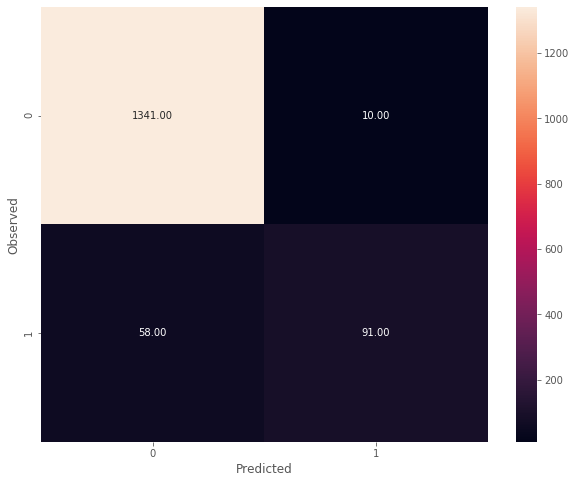

```
None

Recall: 0.610738255033557

Precision: 0.900990099009901

F1 Score: 0.7280000000000001

Roc Auc Score: 0.8016681652665933
```

```python
#The final model is therefore
model = LogisticRegression(random_state=42,penalty='l1', solver='liblinear', class_weight=None,C=1)
model.fit(X_train, y_train)
y_predict = model.predict(X_test)
print("Trainig accuracy",model.score(X_train,y_train))
print()
print("Testing accuracy",model.score(X_test, y_test))
print()
print('Confusion Matrix')
print(draw_cm(y_test,y_predict))
print()
print("Recall:",recall_score(y_test,y_predict))
print()
print("Precision:",precision_score(y_test,y_predict))
print()
print("F1 Score:",f1_score(y_test,y_predict))
print()
print("Roc Auc Score:",roc_auc_score(y_test,y_predict))
```

### Recall, Precision and F1 Score have all been improved. Similary accuracy is slightly better at 96.2% on training data and 95.5% on testing data. No overfitting observed

# 5. Business Understanding

**Confusion matrix means**

*True Positive (observed=1,predicted=1):*

Predicted that presonal loan should be offered and the customer will accept the loan

*False Positive (observed=0,predicted=1):*

Predicted that personal loan should be offered and the customer will not accept the loan

*True Negative (observed=0,predicted=0):*

Predicted that personal loan will not be offered and the customer was not accept the loan

*False Negative (observed=1,predicted=0):*

Predicted that personal loan will not be offered and the customer would have accepted the loan

Since the bank wants to improve/increase the number of customers who will accept the personal loan offer, we want to reduce False Negatives (FN). If FN is high, then it means the bank would not make as much money from the personal loans as we are predicting that customers who would have accepted the loan offer wouldn't accept it. Recall is therefore an important metric that we want to optimize (i.e. get as much true positives as possible correctly). Our current model has a Recall of 61% so we need to improve it before we can deploy to production.

For the False Positive (FP) case, we are predicting that the customer would accept a personal loan while they would not. This would cause no harm to the bank and they would not be loosing any money.